# Python_HW3_boyeonK

### HW3. Numerical Interpolation

### 2022313047 Boyeon,Kim

```python
import numpy as np
import matplotlib.pyplot as plt
from mpl_toolkits.mplot3d import Axes3D
import scipy as sp
```

```python
# Set plot params
plt.rcParams['figure.figsize'] = [10,10]
plt.rcParams['font.size'] = 15
plt.rcParams['font.family'] = 'Times New Roman'
plt.rcParams['axes.linewidth'] = 2
plt.rcParams['lines.linewidth'] = 2
plt.rcParams['xtick.direction'] = 'out'
plt.rcParams['ytick.direction'] = 'out'
plt.rcParams['xtick.minor.visible'] = True
plt.rcParams['ytick.minor.visible'] = True
plt.rcParams['xtick.major.size'] = 7
plt.rcParams['ytick.major.size'] = 7
plt.rcParams['xtick.minor.size'] = 3.5
plt.rcParams['ytick.minor.size'] = 3.5
plt.rcParams['xtick.major.width'] = 1.5
plt.rcParams['ytick.major.width'] = 1.5
plt.rcParams['xtick.minor.width'] = 1.5
plt.rcParams['ytick.minor.width'] = 1.5
plt.rcParams['xtick.top'] = True
plt.rcParams['ytick.right'] = True
```

### 1. Consider the function $f(x, y)=0.26\left(x^2+y^2\right)-0.48 x y$, where $-1 \leq x \leq 1$ and $-1 \leq y \leq 1$.

#### 1. (1). Find and plot the Lagrange interpolating polynomial $p(x,y)$ using equally spaced nodes with $h = 0.2$.

```python
# Define the function
def f1(x, y):
    return 0.26*(x**2 + y**2) - 0.48*x*y
```

```python
# Define the interpolation nodes
node_x = np.arange(-1, 1.1, 0.2)
node_y = np.arange(-1, 1.1, 0.2)
```

```python
# Define the Lagrange basis functions
def lagrange_basis_2d(x, y, k, l, node_x, node_y):
    basis_x = np.ones_like(x)
    basis_y = np.ones_like(y)
    for i in range(len(node_x)):
        if i != k:
            basis_x *= (x - node_x[i]) / (node_x[k] - node_x[i])
        if i != l:
            basis_y *= (y - node_y[i]) / (node_y[l] - node_y[i])
    return basis_x * basis_y
```

```python
x = np.linspace(-1, 1, 101)
y = np.linspace(-1, 1, 101)
X, Y = np.meshgrid(x, y)

# Compute the interpolated values
Z_interp = np.zeros_like(X)
for k in range(len(node_x)):
    for l in range(len(node_y)):
        Z_interp += f1(node_x[k], node_y[l]) * lagrange_basis_2d(X, Y, k, l, node_x, node_y)

print("Interpolated function value: ")
print(Z_interp[0])
```

```
Interpolated function value:
[0.04     0.039304 0.038816 0.038536 0.038464 0.0386   0.038944 0.039496
 0.040256 0.041224 0.0424   0.043784 0.045376 0.047176 0.049184 0.0514
 0.053824 0.056456 0.059296 0.062344 0.0656   0.069064 0.072736 0.076616
 0.080704 0.085    0.089504 0.094216 0.099136 0.104264 0.1096   0.115144
 0.120896 0.126856 0.133024 0.1394   0.145984 0.152776 0.159776 0.166984
 0.1744   0.182024 0.189856 0.197896 0.206144 0.2146   0.223264 0.232136
 0.241216 0.250504 0.26     0.269704 0.279616 0.289736 0.300064 0.3106
 0.321344 0.332296 0.343456 0.354824 0.3664   0.378184 0.390176 0.402376
 0.414784 0.4274   0.440224 0.453256 0.466496 0.479944 0.4936   0.507464
 0.521536 0.535816 0.550304 0.565    0.579904 0.595016 0.610336 0.625864
 0.6416   0.657544 0.673696 0.690056 0.706624 0.7234   0.740384 0.757576
 0.774976 0.792584 0.8104   0.828424 0.846656 0.865096 0.883744 0.9026
 0.921664 0.940936 0.960416 0.980104 1.      ]
```

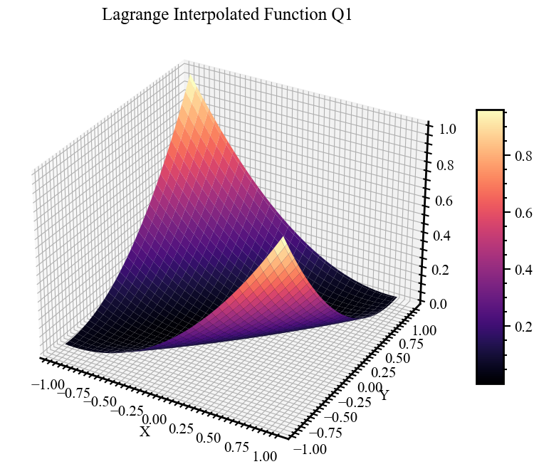

```python
# Plot the results
fig= plt.figure()
ax=fig.add_subplot(111, projection='3d')
surf=ax.plot_surface(X,Y,Z_interp, cmap='magma')
plt.xlabel('X')
plt.ylabel('Y')
plt.title('Lagrange Interpolated Function Q1')
fig.colorbar(surf, shrink=0.5, aspect=10)
plt.show()
```

#### 1.(2). Compare the computed result in Question 1-(1) with the exact function value

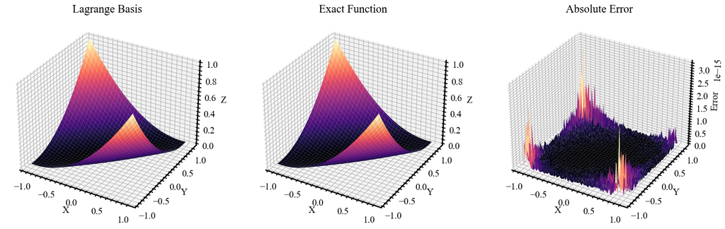

```python
# Compute the exact function values
Z_exact = f1(X, Y)

# Compute the absolute error intp vs. exact
error = np.abs(Z_interp - Z_exact)

# Plot the results
fig = plt.figure(figsize=(20, 6))
ax1 = fig.add_subplot(1, 3, 1, projection='3d')
ax1.plot_surface(X, Y, Z_interp, cmap='magma')
ax1.set_title('Lagrange Basis')
ax1.set_xlabel('X')
ax1.set_ylabel('Y')
ax1.set_zlabel('Z')
ax2 = fig.add_subplot(1, 3, 2, projection='3d')
ax2.plot_surface(X, Y, Z_exact, cmap='magma')
ax2.set_title('Exact Function')
ax2.set_xlabel('X')
ax2.set_ylabel('Y')
ax2.set_zlabel('Z')
ax3 = fig.add_subplot(1, 3, 3, projection='3d')
ax3.plot_surface(X, Y, error, cmap='magma')
ax3.set_title('Absolute Error')
ax3.set_xlabel('X')
ax3.set_ylabel('Y')
ax3.set_zlabel('Error')
plt.show()
```

### 2. Consider the function $f(x, y)=\sin (\pi x) \sin (\pi y)$, where $-1 \leq x \leq 1$ and $-1 \leq y \leq 1$.

#### 2.(1) Find and plot the Lagrange interpolating polynomial $p(x, y)$ using equally spaced nodes with $h=0.2$.

```python
# Define the function
def f2(x, y):
    return np.sin(np.pi * x) * np.sin(np.pi * y)
```

```python
# Define the interpolation nodes
node_x = np.arange(-1, 1.1, 0.2)
node_y = np.arange(-1, 1.1, 0.2)
print(node_x)
```

```
[-1.00000000e+00 -8.00000000e-01 -6.00000000e-01 -4.00000000e-01
 -2.00000000e-01 -2.22044605e-16  2.00000000e-01  4.00000000e-01
  6.00000000e-01  8.00000000e-01  1.00000000e+00]
```

```python
x = np.linspace(-1, 1, 101)
y = np.linspace(-1, 1, 101)
X, Y = np.meshgrid(x, y)

# Compute the interpolated values
Z_interp = np.zeros_like(X)
for k in range(len(node_x)):
    for l in range(len(node_y)):
        Z_interp += f2(node_x[k], node_y[l]) * lagrange_basis_2d(X, Y, k, l, node_x, node_y)

print("Interpolated function value: ")
print(Z_interp[0])
```

```
Interpolated function value:
[ 1.49975978e-32  7.68556235e-18  1.53429821e-17  2.29412752e-17
  3.04498903e-17  3.78387891e-17  4.50785298e-17  5.21403551e-17
  5.89962823e-17  6.56191947e-17  7.19829328e-17  7.80623861e-17
  8.38335823e-17  8.92737748e-17  9.43615270e-17  9.90767935e-17
  1.03400996e-16  1.07317096e-16  1.10809660e-16  1.13864921e-16
  1.16470832e-16  1.18617116e-16  1.20295306e-16  1.21498777e-16
  1.22222777e-16  1.22464445e-16  1.22222821e-16  1.21498851e-16
  1.20295388e-16  1.18617176e-16  1.16470832e-16  1.13864824e-16
  1.10809434e-16  1.07316718e-16  1.03400461e-16  9.90761180e-17
  9.43607575e-17  8.92729905e-17  8.38328984e-17  7.80619532e-17
  7.19829328e-17  6.56198306e-17  5.89977609e-17  5.21428596e-17
  4.50821807e-17  3.78435902e-17  3.04556553e-17  2.29475321e-17
  1.53488507e-17  7.68959806e-18  2.57092269e-37 -7.68959806e-18
 -1.53488507e-17 -2.29475321e-17 -3.04556553e-17 -3.78435902e-17
 -4.50821807e-17 -5.21428596e-17 -5.89977609e-17 -6.56198306e-17
 -7.19829328e-17 -7.80619532e-17 -8.38328984e-17 -8.92729905e-17
 -9.43607575e-17 -9.90761180e-17 -1.03400461e-16 -1.07316718e-16
 -1.10809434e-16 -1.13864824e-16 -1.16470832e-16 -1.18617176e-16
 -1.20295388e-16 -1.21498851e-16 -1.22222821e-16 -1.22464445e-16
 -1.22222777e-16 -1.21498777e-16 -1.20295306e-16 -1.18617116e-16
 -1.16470832e-16 -1.13864921e-16 -1.10809660e-16 -1.07317096e-16
 -1.03400996e-16 -9.90767935e-17 -9.43615270e-17 -8.92737748e-17
 -8.38335823e-17 -7.80623861e-17 -7.19829328e-17 -6.56191947e-17
 -5.89962823e-17 -5.21403551e-17 -4.50785298e-17 -3.78387891e-17
 -3.04498903e-17 -2.29412752e-17 -1.53429821e-17 -7.68556235e-18
 -7.41851694e-33]
```

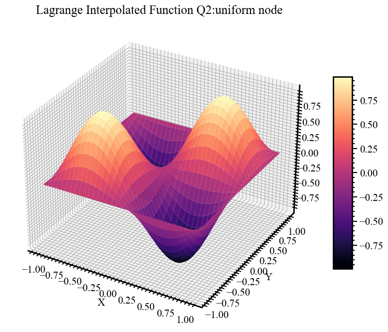

```python
# Plot the results
fig= plt.figure()
ax=fig.add_subplot(111, projection='3d')
surf=ax.plot_surface(X,Y,Z_interp, cmap='magma')
plt.xlabel('X')
plt.ylabel('Y')
plt.title('Lagrange Interpolated Function Q2:uniform node')
fig.colorbar(surf, shrink=0.5, aspect=10)
plt.show()
```

#### 2.(2) Compare the computed result in Question 2-(1) with the exact function value.

```
가장 큰 error :
5.194604921249235e-05
```

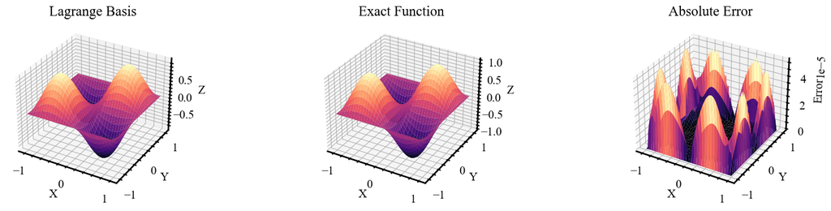

```python
# Compute the exact function values
Z_exact = f2(X, Y)

# Compute the absolute error intp vs. exact
error1 = np.abs(Z_interp - Z_exact)
print("가장 큰 error : ")
print(np.max(error1))

# Plot the results
fig = plt.figure(figsize=(20, 4))
ax1 = fig.add_subplot(1, 3, 1, projection='3d')
ax1.plot_surface(X, Y, Z_interp, cmap='magma')
ax1.set_title('Lagrange Basis')
ax1.set_xlabel('X')
ax1.set_ylabel('Y')
ax1.set_zlabel('Z')
ax2 = fig.add_subplot(1, 3, 2, projection='3d')
ax2.plot_surface(X, Y, Z_exact, cmap='magma')
ax2.set_title('Exact Function')
ax2.set_xlabel('X')
ax2.set_ylabel('Y')
ax2.set_zlabel('Z')
ax3 = fig.add_subplot(1, 3, 3, projection='3d')
ax3.plot_surface(X, Y, error1, cmap='magma')
ax3.set_title('Absolute Error')
ax3.set_xlabel('X')
ax3.set_ylabel('Y')
ax3.set_zlabel('Error')
plt.show()
```

#### 2.(3) Do the same work with the Chebyshev nodes,

$$ x_i=\cos \left(\frac{2 i+1}{2 n+2} \pi\right), \quad y_j=\cos \left(\frac{2 j+1}{2 n+2} \pi\right), \quad i=0,1, \ldots, n, j=0,1, \ldots, m . $$

```python
# Define the number of nodes in each dimension
n = 10
m = 10

# Generate the Chebyshev nodes in each dimension
chv_x = np.cos((2*np.arange(0, n+1) + 1)*np.pi/(2*(n+1)))
chv_y = np.cos((2*np.arange(0, m+1) + 1)*np.pi/(2*(m+1)))
print(chv_x)
```

```
[ 9.89821442e-01  9.09631995e-01  7.55749574e-01  5.40640817e-01
  2.81732557e-01  2.83276945e-16 -2.81732557e-01 -5.40640817e-01
 -7.55749574e-01 -9.09631995e-01 -9.89821442e-01]
```

```python
# Compute the interpolated values
Z_interp = np.zeros_like(X)
for k in range(len(chv_x)):
    for l in range(len(chv_y)):
        Z_interp += f2(chv_x[k], chv_y[l]) * lagrange_basis_2d(X, Y, k, l, chv_x, chv_y)

print("Interpolated function value: ")
print(Z_interp[0])
```

```
Interpolated function value:
[ 3.20562413e-11  3.55489807e-07  7.09582390e-07  1.06089492e-06
  1.40802913e-06  1.74960756e-06  2.08427785e-06  2.41071717e-06
  2.72763676e-06  3.03378644e-06  3.32795911e-06  3.60899519e-06
  3.87578700e-06  4.12728292e-06  4.36249150e-06  4.58048528e-06
  4.78040445e-06  4.96146028e-06  5.12293820e-06  5.26420071e-06
  5.38468993e-06  5.48392984e-06  5.56152823e-06  5.61717825e-06
  5.65065972e-06  5.66183996e-06  5.65067443e-06  5.61720681e-06
  5.56156896e-06  5.48398032e-06  5.38474706e-06  5.26426090e-06
  5.12299751e-06  4.96151464e-06  4.78044990e-06  4.58051823e-06
  4.36250903e-06  4.12728307e-06  3.87576904e-06  3.60895988e-06
  3.32790885e-06  3.03372537e-06  2.72757060e-06  2.41065288e-06
  2.08422297e-06  1.74956907e-06  1.40801178e-06  1.06089888e-06
  7.09600026e-07  3.55501349e-07 -1.06618221e-25 -3.55501349e-07
 -7.09600026e-07 -1.06089888e-06 -1.40801178e-06 -1.74956907e-06
 -2.08422297e-06 -2.41065288e-06 -2.72757060e-06 -3.03372537e-06
 -3.32790885e-06 -3.60895988e-06 -3.87576904e-06 -4.12728307e-06
 -4.36250903e-06 -4.58051823e-06 -4.78044990e-06 -4.96151464e-06
 -5.12299751e-06 -5.26426090e-06 -5.38474706e-06 -5.48398032e-06
 -5.56156896e-06 -5.61720681e-06 -5.65067443e-06 -5.66183996e-06
 -5.65065972e-06 -5.61717825e-06 -5.56152823e-06 -5.48392984e-06
 -5.38468993e-06 -5.26420071e-06 -5.12293820e-06 -4.96146028e-06
 -4.78040445e-06 -4.58048528e-06 -4.36249150e-06 -4.12728292e-06
 -3.87578700e-06 -3.60899519e-06 -3.32795911e-06 -3.03378644e-06
 -2.72763676e-06 -2.41071717e-06 -2.08427785e-06 -1.74960756e-06
 -1.40802913e-06 -1.06089492e-06 -7.09582390e-07 -3.55489807e-07
 -3.20562331e-11]
```

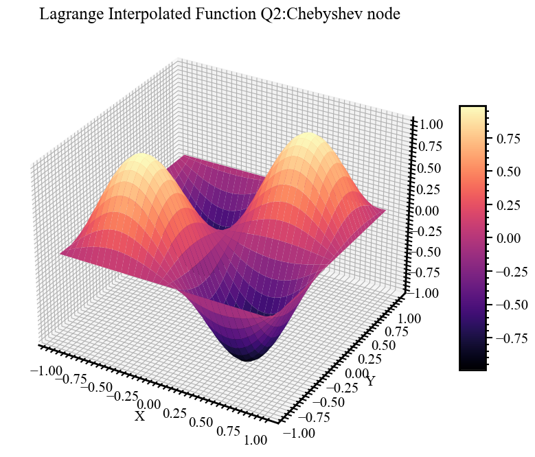

```python
# Plot the results
fig= plt.figure()
ax=fig.add_subplot(111, projection='3d')
surf=ax.plot_surface(X,Y,Z_interp, cmap='magma')
plt.xlabel('X')
plt.ylabel('Y')
plt.title('Lagrange Interpolated Function Q2:Chebyshev node')
fig.colorbar(surf, shrink=0.5, aspect=10)
plt.show()
```

```
가장 큰 error :
1.1553442636591527e-05
```

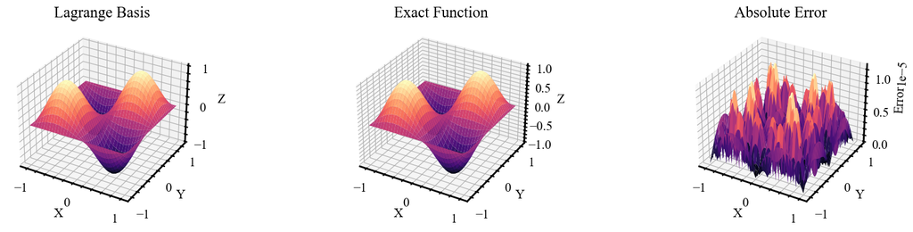

```python
# Compute the exact function values
Z_exact = f2(X, Y)

# Compute the absolute error intp vs. exact
error2 = np.abs(Z_interp - Z_exact)
print("가장 큰 error : ")
print(np.max(error2))

# Plot the results
fig = plt.figure(figsize=(20, 4))
ax1 = fig.add_subplot(1, 3, 1, projection='3d')
ax1.plot_surface(X, Y, Z_interp, cmap='magma')
ax1.set_title('Lagrange Basis')
ax1.set_xlabel('X')
ax1.set_ylabel('Y')
ax1.set_zlabel('Z')
ax2 = fig.add_subplot(1, 3, 2, projection='3d')
ax2.plot_surface(X, Y, Z_exact, cmap='magma')
ax2.set_title('Exact Function')
ax2.set_xlabel('X')
ax2.set_ylabel('Y')
ax2.set_zlabel('Z')
ax3 = fig.add_subplot(1, 3, 3, projection='3d')
ax3.plot_surface(X, Y, error2, cmap='magma')
ax3.set_title('Absolute Error')
ax3.set_xlabel('X')
ax3.set_ylabel('Y')
ax3.set_zlabel('Error')
plt.show()
```

### Discussion

(2)번의 결과와 비교해 보면, (2)번의 결과는 node의 양 끝점으로 갈수록 Error가 큰 것을 볼 수 있다.  
이에 반해 (3)번의 결과를 보면 중앙쪽에서 에러가 크고 끝 점에서는 다소 작은 것을 볼 수 있다.  
특히, (2)번보다 (3)번의 가장 큰 error의 값 차이는 약 5배 작은 것을 볼 수 있다.  
이러한 현상은 interpolation하는 node의 특징에 의해 나타난다.

#### 2.(4) Discuss why the Chebyshev nodes are generally better than equally spaced nodes in polynomial interpolation. [Hint: Plot the functions $\prod^n\left|x-x_i\right|$ for uniform and Chebyshev nodes.]

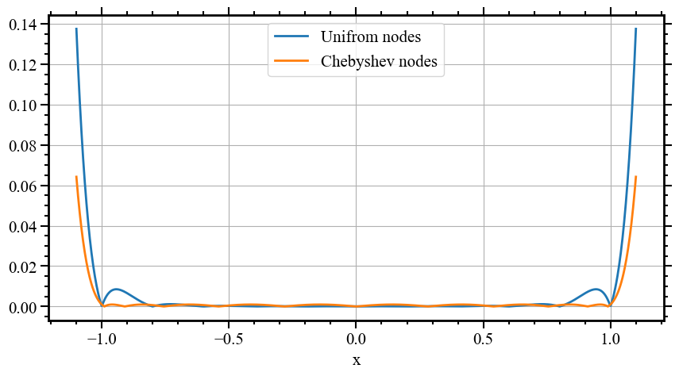

```python
# np.newaxis : numpy array 차원 늘려줌
# x와 node를 연산 하기 위해
# reshape와의 차이는 차원의 합이 동일하지 않아도 됨!
def f3(x, node):
    return np.prod(np.abs(x - node[:, np.newaxis]), axis=0)

x = np.linspace(-1.1, 1.1, 1000)

# node_x : uniform node (-1, 1, 0.2)
# chv_x : Chebyshev node
plt.figure(figsize=(10, 5))
plt.plot(x, f3(x, node_x), label = 'Unifrom nodes')
plt.plot(x, f3(x, chv_x), label = 'Chebyshev nodes')
plt.xlabel('x')
plt.grid()
plt.legend()
plt.show()
```

### Discussion

위의 그림을 보면,  
Chebyshev node는 uniform node에 비해 variation이 적은 것을 볼 수 있다.  
특히 중앙값에서는 uniform node의 variation이 적어보이나, node의 끝 점으로 갈때 크게 변동한다.  
이러한 현상을 'runge 현상'이라 부르는데, Chebyshev node는 이 현상이 uniform node보다 적은 것을 볼 수 있다.  
이러한 차이는 interpolation을 할 때, ocsillation을 줄일 수 있고 정확한 근사치를 내는데에 더욱 도움을 준다.  
앞선 (2), (3)의 absolute error 그래프가 이러한 현상을 잘 설명해주고 있다.